# 有关无偏估计的解释

shutian

2023/10/14

此pdf用以解释无偏统计量的概念，大部分选课的同学还没有学过概率统计，所以此pdf从比较基础的部分开始讲起，也会涉及到Lecture4中有关期望和方差的数学推导。同时也会证明为什么样本方差的计算方法是无偏的，但是df=n-1的样本标准差的计算方法是有偏的。

#### 有关期望的理解

##### 期望的定义

期望是针对随机变量而言的一个量，可以理解成是站在”上帝视角”的值，它是一种概率论的概念，是一个数学的特征，首先我们给出其定义公式：

$离散型随机变量X的取值为X_1,X_2,X_3,…,X_n,X取对应值的概率P(X_1),P(X_2),P(X_3),P(X_n)，则$
$$E(X) =
X_1*P(X_1)+X_2*P(X_2)+…+X_n*P(X_n)=\sum_{k=1}^{n}X_k*P(X_k)
\tag{1}$$

##### 期望与均值之间的联系

均值，其实是针对实验观察到的特征而言，比如实验结果得到了$x_1$,$x_2$,$x_3$,…,$x_n$这n个值，那么均值则是$m = 1/n*(x_1+...+x_n)$。比如我们进行掷骰子，掷了六次，点数分别为1，1，1，3，3，3，这六次的观察就是我们的**样本**，于是我们可以说 **均值**为(1+1+1+3+3+3)/6=2，但这并不意味着掷骰子，每次掷骰子点数期望值为2。因为在这里并未考虑到掷一次骰子得到不同点数的概率。所以**均值**仅仅是针对观测值而言。

但这并不意味着期望与均值毫无联系。当我们掷骰子的次数逐渐增多，会发现我们观察到的样本里，不同点数出现的次数(频率,frequency)比较接近(假设这个骰子是均匀的，那么每一面朝上的概率都是相等的)，样本量越大，频率可能约接近概率(这一点也叫作大数定理)。在此时计算均值时，会发现样本的均值和真实的数学期望比较接近。比如1,2,3,4,5,6朝上的次数分别为1000,1010,999,995,992,1004，此时**均值**是:
$$m=(1*1000+2*1010+3*999+4*995+5*992+6*1004)/6000=3.497$$
而掷骰子的数学期望则是:
$$E(X) =
1*1/6+2*1/6+…+6*1*6=3.5$$
二者之间的差值已经很小，随着样本数目的增大，样本均值会比较接近随机变量的数学期望。所以可以认为**数学期望是样本均值在样本量趋于无穷大的极限**

#### 有关方差的理解

在概率论的视角，假设一个随机变量X的期望值为$\mu$，则方差的定义式为：
$$Var(X) = E(X-u)^2 = E(X^2)-[E(X)]^2
\tag{2}$$
有关第二个等号的证明过程，大家可以看一下Lecture4中相关的证明：

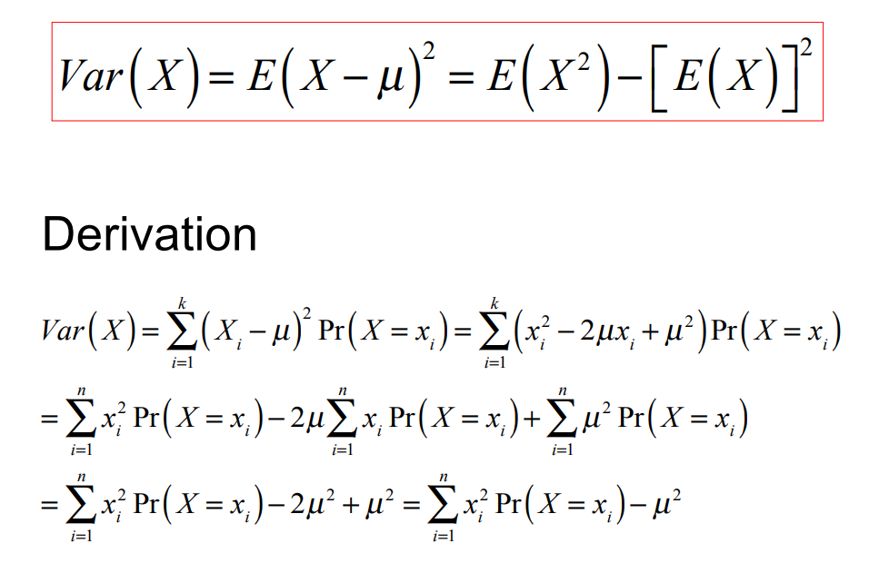

只不过，在实际抽样问题时，我们对于一个样本倾向于计算方差减去的是样本的均值。

#### 对于无偏统计量的理解

有了以上对于期望和方差一些数学理解，我们来介绍什么是无偏估计，并利用数学推导证明以下三个结论：  
- 样本均值是总体均值的无偏估计量  
- 样本方差(df=n-1)是总体方差的无偏估计量  
- 利用df=n-1算得的样本标准差是总体标准差的有偏估计量

**什么是无偏估计**：无偏估计量是用样本统计量来估计总体参数时的一种无偏推断。**样本估计量的数学期望**等于**被估计参数的真实值**，则成此估计量为被估计参数的无偏估计。具体可见：[无偏估计_百度百科 (baidu.com)](https://baike.baidu.com/item/%E6%97%A0%E5%81%8F%E4%BC%B0%E8%AE%A1/3370664)，如果样本统计量的数学期望不等于被估计参数的真实值，则我们认为其实有偏的。下面我们分别证明上述提到的三个结论：

假设对于总体，其随机变量X的数学期望为$\mu$,方差为$\sigma^2$，我们从中抽样，$X_1,X_2,..,X_n$分别为样本中不同数据点的值，彼此之间独立(注意这里的$X_i$和期望定义的$X_i$指的不是一个内容，期望定义时，$X_i$表示的是可以取的不同值，而此时定义的$X_i$表示的是每个观测点的值，也可以认为我们有n个随机变量X。

**证明1：样本均值是总体均值的无偏估计量** 对于一个样本，我们有：
$$m = \frac{\sum_{k=1}^{n}X_i}{n}
\tag{3}$$
我们想要说明m是无偏估计量，只需证明：
$$E(m) = \mu
\tag{4}$$
下面即为证明：
$$E(m) = E(\frac{\sum_{k=1}^{n}X_i}{n}) = \frac{1}{n}*(E(X_1)+…+E(X_n))
\tag{5}$$

又因为对于每一个$X_i$，都有$E(X_i) = E(X) = \mu$，所以上式转化为：
$$E(m) = \frac{1}{n}*(n*\mu)=\mu
\tag{6}$$
所以我们认为样本均值是总体均值的无偏估计

**证明2：样本方差是总体方差的无偏估计量** 对于一个样本，假设样本均值为$m$，我们有：
$$s^2 = \frac{\sum_{k=1}^{n}(X_i-m)^2}{n-1}
\tag{7}$$

下面即为证明:
$$\begin{align*}
E(s^2) &= E(\frac{\sum_{k=1}^{n}(X_i-m)^2}{n-1})\\
&=\frac{1}{n-1}E(\sum_{k=1}^n(X_i^2-2mX_i+m^2)) \\
&=\frac{1}{n-1}E(\sum_{k=1}^nX_i^2-nm^2)(因为\sum X_i= n*m)\\
&= \frac{1}{n-1}(\sum_{k=1}^{n}E(X_i^2)-nE(m^2))
\tag{9}
\end{align*}$$

而由上述(2)式,$Var(X) = E(X-u)^2 = E(X^2)-[E(X)]^2$ 我们有：

$$\begin{align*}
E(X_i^2) &= Var(X_i)+[E(X_i)]^2=\sigma^2+\mu^2\\
E(m^2) &= Var(m)+[E(m)]^2 = \frac{\sigma^2}{n}+\mu^2 \\
Var(m) &= \frac{\sigma^2}{n}证明见(12)
\tag{10}
\end{align*}$$

带入(9)，我们有：
$$\begin{align*}
E(s^2) &= \frac{1}{n-1}(\sum_{k=1}^{n}E(X_i^2)-nE(m^2)) \\
&= \frac{1}{n-1}(n*\sigma^2+n*\mu^2-n*(\frac{\sigma^2}{n}+\mu^2)) \\
&= \sigma^2
\tag{11}
\end{align*}$$

所以我们证明了，有关样本方差的确是总体方差的无偏统计量。下面补充(12)式:

$$\begin{align*}
Var(m) &= Var(\frac{\sum_{k=1}^{n}X_i}{n}) \\
&= \frac{1}{n}Var(X)\\
&= \frac{\sigma^2}{n{}}
\tag{12}
\end{align*}$$

**证明3：利用df=n-1算得的样本标准差是总体标准差的有偏估计量**